# Affordability of Residential Real Estate in Warsaw

**R-Bootcamp Project – W.MSCIDS_RB01.H2501**

Alena Ploshchansky · Rita Ahlborn

*Master of Science in Real Estate*

*Minor in Data Science*

Lucerne University of Applied Sciences and Arts

January 28, 2026

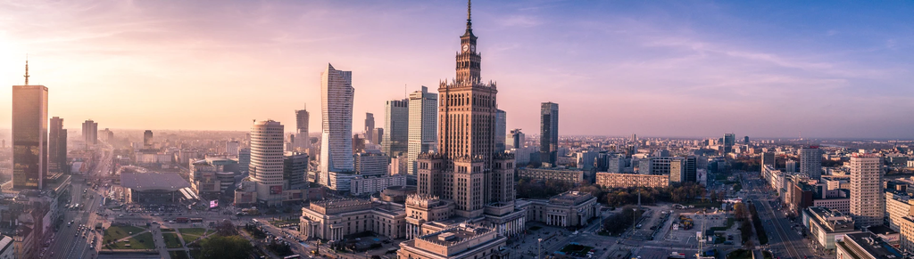

*Warsaw Skyline*

## **3. Data Preparation**

In this chapter we describe the datasets we have as well as prepare it for further analysis. We clean it, transform it and merge it into one final dataset.

### 3.1 Data Cleaning and transformation

This chapter is dedicated to cleaning and transforming each dataset separately. After all the manipulations we will have three clean datasets ready for merging. We will merge them in this chapter as well. We have 3 datasets: prices, density, median_wage.

#### *3.1.1 Price Data*

Here we check for missing values and clean the data. We remove columns that are not needed.

#### *3.1.2 Wage Data*

Here we clean the wage data set and convert it to quarterly median wage.

### 3.2 Data merging

Here we merge the three cleaned datasets into one final dataset for analysis.

## **4. Data Analysis**

The empirical analysis builds on the prepared dataset to explore patterns in residential real estate affordability in Warsaw. The analysis combines numerical summaries and visual representations to examine both the distribution and spatial variation of key variables. These exploratory insights provide context for understanding how prices, income levels, and urban structure differ across the city and how these differences shape affordability outcomes.

### 4.1 Descriptive Statistics

The descriptive analysis presents the main characteristics of the data using formats tailored to the nature of each variable. Transaction-level price data allow for a detailed examination of distributional properties, while wage and population density data, observed at aggregated spatial levels, are better described through levels and spatial patterns. Together, these descriptive elements offer an initial empirical overview of affordability-related dynamics within Warsaw.

#### *4.1.1 Transaction Price Data*

Residential prices per square meter represent the **central variable** of interest in the analysis and therefore receive a more detailed descriptive treatment. Summary statistics are used to illustrate typical price levels, variability, and the presence of extreme values, while graphical representations highlight the overall shape of the price distribution. This allows for an initial assessment of market heterogeneity and provides context for the district-level comparisons presented later in the analysis.

The summary statistics describe residential transaction prices expressed in Polish zloty per square meter (PLN/m²) and provide an overview of typical price levels and dispersion in the Warsaw housing market. The **mean price** amounts to approximately **15 624 PLN/m²**, while the median is slightly lower at **15 270 PLN/m²**, indicating that higher-priced observations increase the average relative to the typical transaction. The difference between the mean and median suggests a **right-skewed price distribution**, where a limited number of very high-priced dwellings—often associated with particularly attractive locations or specific market segments. The standard deviation of **3 481 PLN/m²** points to substantial variability in prices across transactions.

The observed price range, spanning from **4 513 PLN/m²** to **41 176 PLN/m²**, highlights pronounced heterogeneity within the market, reflecting strong differences in location, neighborhood characteristics, and housing quality. Overall, these statistics indicate that the median price provides a more representative measure of typical affordability conditions, while the mean captures the influence of the upper tail of the price distribution.

Summary Statistics for Price/m²

| Statistics | Value |
| --- | --- |
| Mean | 15 623,74 |
| Median | 15 269,52 |
| Standard Deviation | 3 480,86 |
| Min | 4 513,22 |
| Max | 41 176,00 |

##### **Distribution of Prices per Square Meter**

The distribution of residential prices per square meter in Warsaw is *right-skewed*, indicating the presence of a relatively small number of very high-priced observations. The mean price exceeds the median, which confirms the positive skewness of the distribution. Most observations are concentrated within one standard deviation around the mean, while a long right tail reflects “premium” properties with substantially higher prices per square meter. This suggests that average prices are influenced by high-end segments of the market, whereas the median better represents typical transaction values.

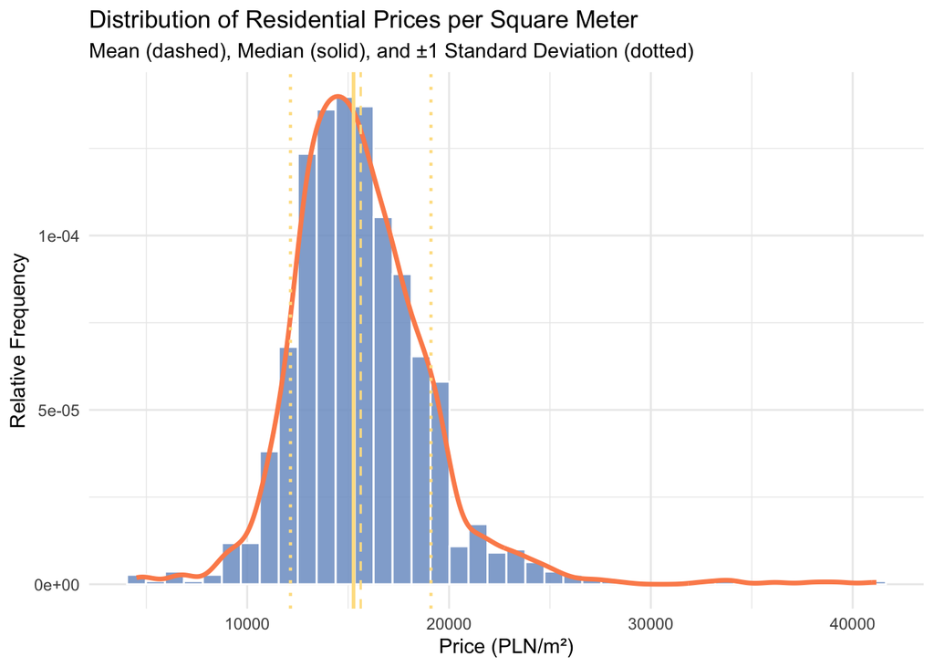

##### **Distribution of Prices per Square Meter by District**

The map reveals pronounced **spatial disparities** in residential prices per square meter across Warsaw’s districts. The highest median prices are concentrated in the **city center**, with *Śródmieście* clearly standing out as the most expensive district, reflecting its centrality, concentration of economic activity, and access to urban amenities. Beyond the city core, *Wilanów* emerges as a notable **high-price district** despite its more peripheral location. This suggests that **price levels are not driven by centrality alone**, but also by housing quality, recent development patterns, and neighborhood prestige, which are characteristic of Wilanów’s predominantly modern and high-standard residential stock. In contrast, *Mokotów*, while still relatively expensive, exhibits lower median prices than Wilanów, highlighting **heterogeneity** even among traditionally high-value districts.

Lower median prices are observed in outer districts such as *Wawer*, *Białołęka*, and *Ursus*, which are characterized by lower density, greater distance from the city center, and more suburban development patterns. Overall, the spatial distribution reflects a **core–periphery structure** with important local deviations, underscoring the role of both location and neighborhood-specific attributes in shaping residential property prices in Warsaw.

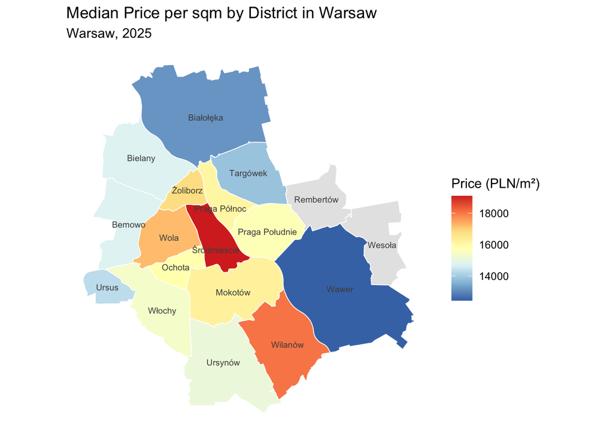